# Changing Metabolic Rates for Longevity

Sophia Lee (sophiale)

4/6/2021

# Introduction

**(1)** One of the most burning questions that everyone has certainly thought about at least once is: is it possible to live forever? Most likely not… But Preston Joregeson is definitely intrigued by this possibility and so are we. We wonder: what factors are there that we can learn from animals and their anatomy to elongate a human’s lifespan as long as we can? Perhaps we need to specificially consider metabolic rates, as suggested by some research. Thus, this report will thoroughly look into these claims and will use models and analyses to answer the following questions:

**Research Questions:**

1. Is there evidence that supports the claim: Slowing the metabolic rate (eg. by intermittent fasting) may increase lifespan?
2. Is there a relationship between metablic rate and lifespan and is it nonlinear? Even after transformations?
3. If we reduce a crab-eating racoon’s (Procyon cancirvorus, HAGRID = 1898) metabolic rate by 50%, what is its estimated mean life span?

The objective of this report is to review the AnAge data to answer these questions to ultimately uncover which factors are related to lifespan to attain the dream of immortality. **(2)** The AnAge Database of Animal Ageing and Longevity is a “curated database of ageing and lifehistory in animals” that was “primarily developed for comparative biology studies”. This report will analyze 347 observations of 14 variables from an AnAge data file called the ‘anage-chordata-data.csv’. It contains information of animals in the Chordata phylum (animals with spinal cords). Entries with missing variables were removed. The variables are:

**Variables**

*HAGRID*: Human Ageing Genomic Resources ID (A unique ID for each entry).

*Kingdom*: the taxonomic classication of the species (also for variables: *phylum, class, order, family genus*, and *species*).

*Common.name*: common name for the animal (the name used by ordinary people, not scientists).

*Maximum.longevity.yrs*: maximum longevity (lifespan), in years.

*Body.mass.g*: typical adult body mass, in grams.

*Metabolic.rate*: typical resting metabolic rate (rate of energy use) in Watts.

*Temperature*: typical body temperature in Kelvin.

**(3)** Overall, the final findings of this report will include the discussion of the distribution of a specie’s maximum longevity lifespan and their metabolic rate. We will also look into the relationship (before and after transformation) between metabolism rates and maximum lifespans, and how it’s non linear but negatively correlated. In addition, this report will uncover how a crab-eating raccoon’s lifespan is affected if its metabolic rate reduces by 50% and how it is actually expected to live about 1 year more from this change.

# Exploratory Data Analysis

**(1)** We first create a new variable called ‘Metabolic.by.mass’. This variable divides variable ‘Metabolic.rate’ by ‘Body.mass.g’, which is the amount of energy used per unit of body mass. This would allow us to compar animals of different sizes. We will use ‘Metabolic.by.mass’ instead of ‘Metabolic.rate’ for the rest of the report.

**(2)** The key variables that we explore for the research questions are: ‘Metabolic.by.mass’ and ‘Max.longevity.yrs’. ‘Max.longevity.yrs’ is the observation’s maximum lonevity of lifespan measured in years. To execute univariate EDA on these variables, **(5)** we’ll use the summary of their data points and histograms to display these variables for it is necessary to understand their distribution and their characteristics within the AnAge data.

The summary statistics of ‘Maximum.longevity.yrs’ is: the minimum lifespan is 2.5 years, the maximum is 122.5 years, the median is 12.9 years, and the mean is 16.01 years.

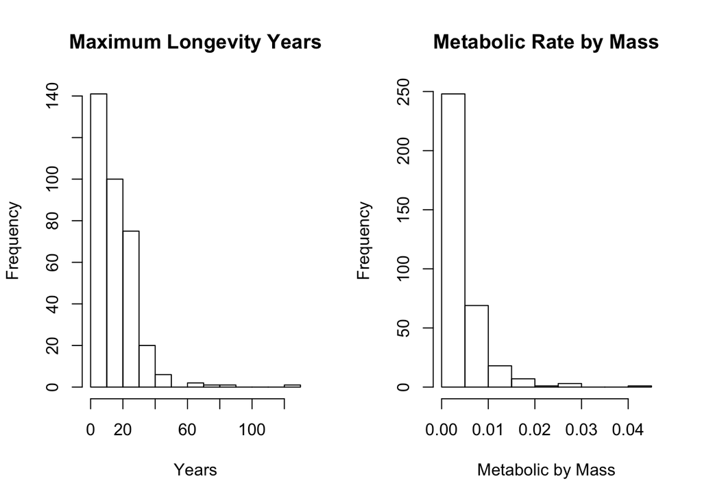

Histograms of key variables

Looking at the histograms from Figure 1, both variables are heavily skewed to the right with a long tail. Notice how the histogram of metabolic by mass exponentailly decreases in frequency when metabolic by mass increases by 0.005, whereas **(3)** the histogram of maximum longevity years start to exponentially decrease when it passes 30 years. To answer our research questions, our response variable will be the maximum longevity years, and our main explanatory variable is metabolic by mass. **(5)** Let’s explore further by observing their box plots:

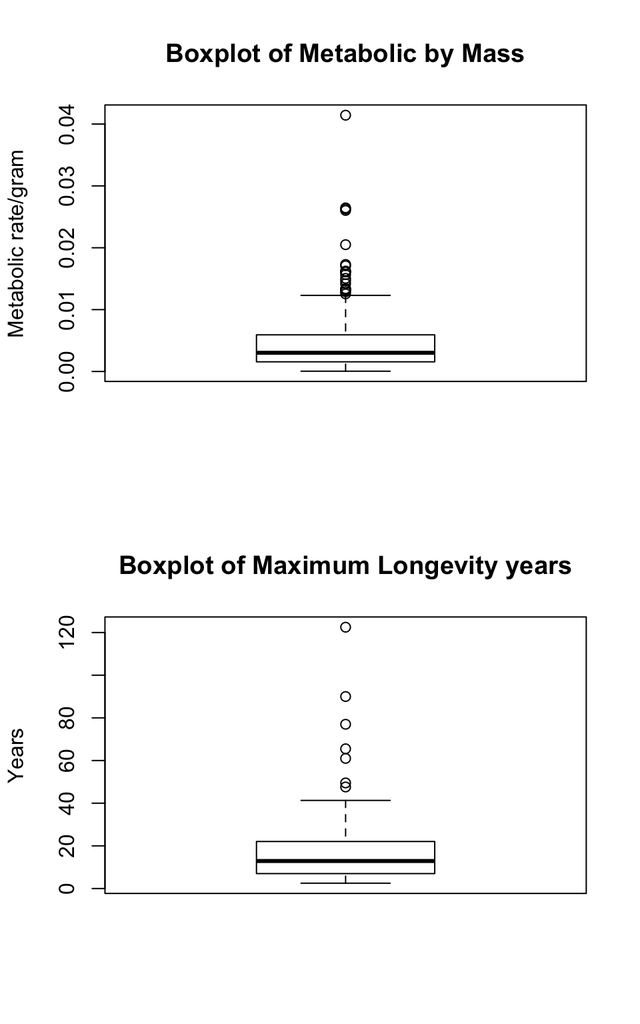

**(2)** Boxplots are important to have a deeper insight into the variables’ distribution. Here, we can instantly notice how both variables contains many outliers. This strongly implies that we should transform these data points to improve data quality.

**(4)**Next we’ll execute a multivariate EDA to explore the relationship between Metabolic by Mass and Maximum Longevity Years. **(5)** We’ll use a scatter plot to visualize their association with each other, which is shown in Figure 2.

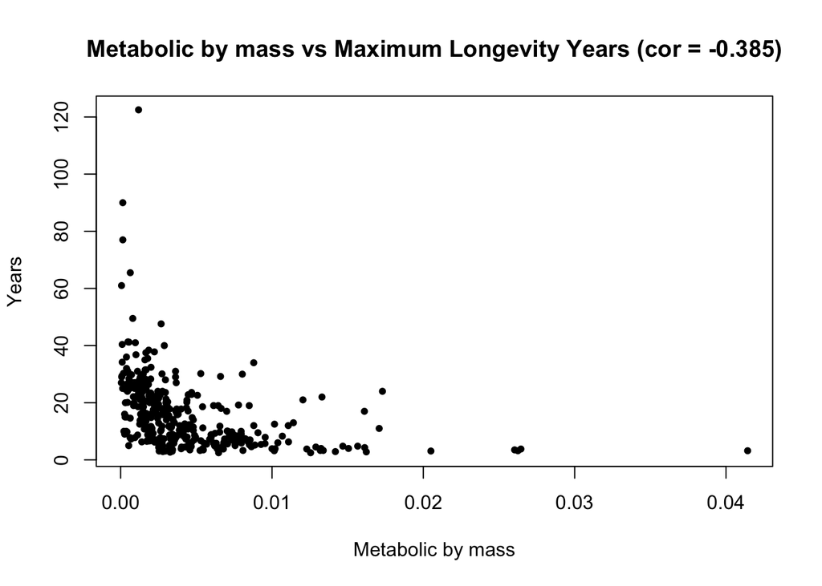

Scatter plot of key variables & Correlation

The scatter plot from Figure 2 shows that there doesn’t exist a linear relationship between ‘Metabolic.by.mass’ and ‘Maximum.longevity.yrs’ with its low correlation of -0.385. There is, however, an attempt of a negative correlated association and there are many outliers from the clump formed in the bottom left corner of the plot. Our key observations so far: there are many signs of outliers from both scatter plots and box plots we made for multivariate EDA, and there are heavily skewed distribution with a long tail from our histograms we made for univariate EDA. Thus, both multivariate and univariate EDAs strongly imply to transform both ‘Metabolic.by.mass’ and ‘Maximum.longevity.yrs’ using log. Log will allow the data to be normalized and more linear. In that case, new variables will be created and added to our AnAge data: ‘log_max.long.yrs’ and ‘log_metabolic.by.mass’. **(5)** Then, let’s see how these transformed variables interact and observe their association, which is shown in Figure 3.

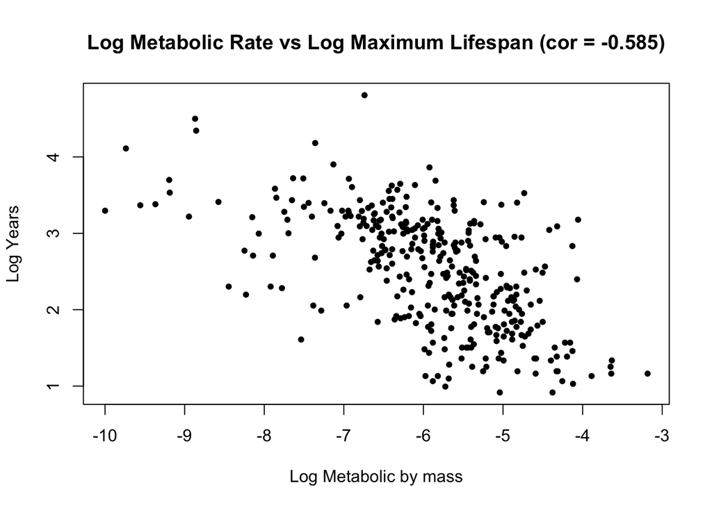

Scatter plot of transformed variables & Correlation

The new scatter plot from Figure 3 with the transformed variables heavily improved from the previous scatter plot. There are more clear components to observe such as its explicit linear relationship with a stronger correlation of -0.585. There is more of a clump when the log(metabolic.by.mass) is from -4 to -7 with a good amount of outliers lower than -7. Though there is much more to explore on this data, we will use these transformed data from this point on of this analysis report due to the data’s improved distribution.

**(6)** To further analyze how these transformations affected the data, **(5)** we will execute boxplots once again on these variables, which is shown in Figure 4.

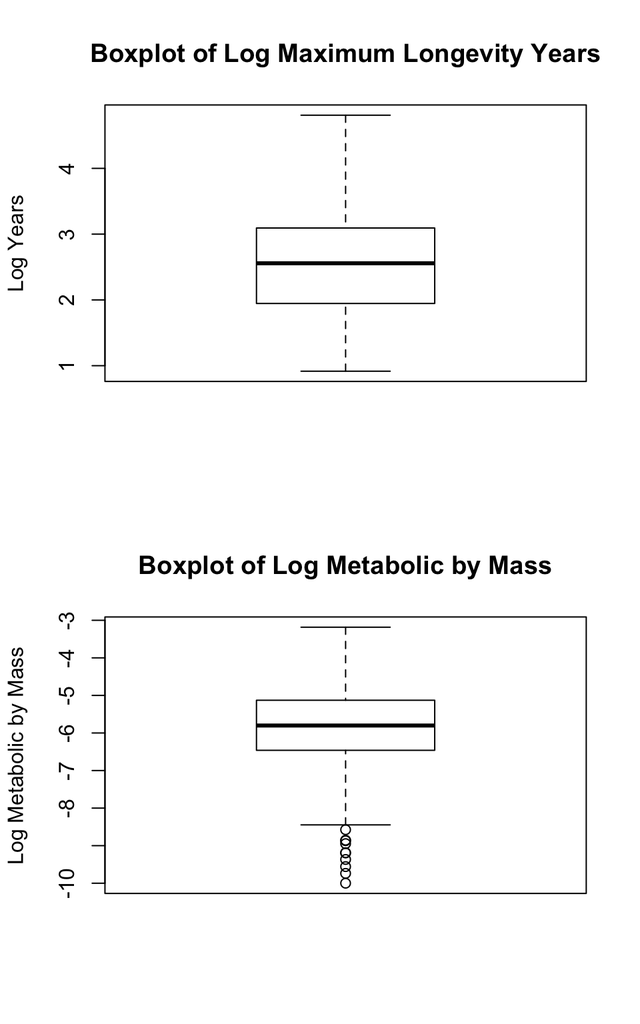

Boxplots of Transformed Variables

Here we can see that the log transformation indeed improve the data points for Maximum Longevity years since there are no signs of outliers. However, we can see that in the Box Plot for Log Metabolic by Mass still has outliers. This is intriguing for the report for this implies there will be interesting findings on our research questions as we further analyze this data with these transformed data.

# Modeling & Diagnostics

Let’s now make a linear model to predict ‘Maximum.longevity.yrs’ using ‘Metabolic.by.mass’ with their transformed versions. First we will make a linear model with these transformed variables and make a scatter plot again like we did for Figure 3.

**(1)** Let $M = log(Maximum.longevity.yrs)$ and $R = log(metabolic.by.mass)$. Thus our linear model is:
$$M \sim \beta_0 + \beta_1 * R$$

Then we’ll add a red fitted line that can be created from the linear model we just made. This new plot is shown on Figure 5.

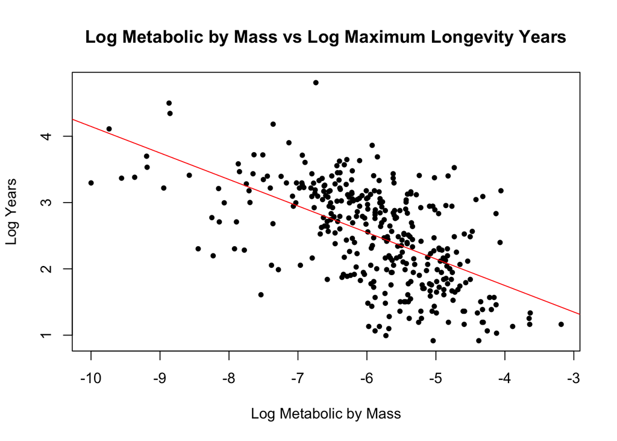

Scatter Plot of Log Metabolic by Mass and Log Maximum Longevity Years with Fitted Line

The scatter plot with the red fitted line (Figure 5) shows that it does an only decent job of showing its relationship. However, the data points are not strongly correlated enough to make accurate predictions using the red fitted line. There is still much more room for improvement to make better predictions. **(2)** Thus, we will use smoothing spline to make improvement on the fitting of the plot of log Maximum Longevity of Years and log of Metabolic by Mass. Smoothing spline will create more flexible fitted lines so that it is much more effective to understand the variable’s relationship. We’ll do this by first fitting five models with different effective degrees of freedom (df): 3, 4, 5, 6, 7. Then we’ll create smoothing splines based on the degrees of freedom and see how all the different lines fit the data. This is shown on Figure 6.

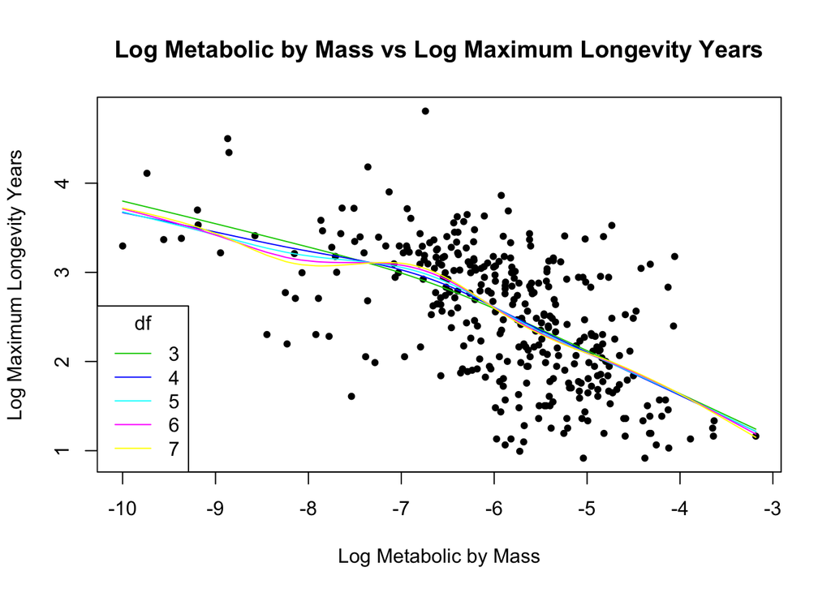

Scatter Plot with Smoothing Splines

Let’s further analyze the models to determine which model is the best fit for the data. **(3)** We can do this by observing their prediction error by using cross-validation with five-folds and by comparing the linear models with the spline models. This method will allow us to compare average prediction errors and standard errors between the models. We will indicate the best model by finding the model with the lowest average prediction error. First, let’s see how the models’ prediction error and standard error compare through graphs:

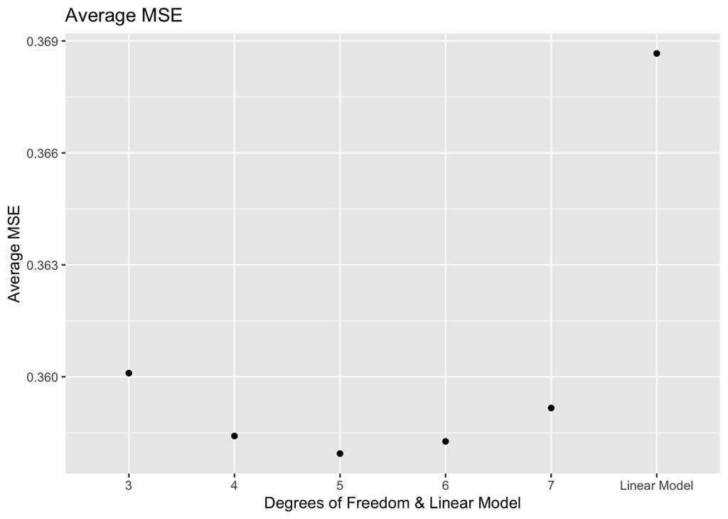

Data Frame of All Average MSE and SSD

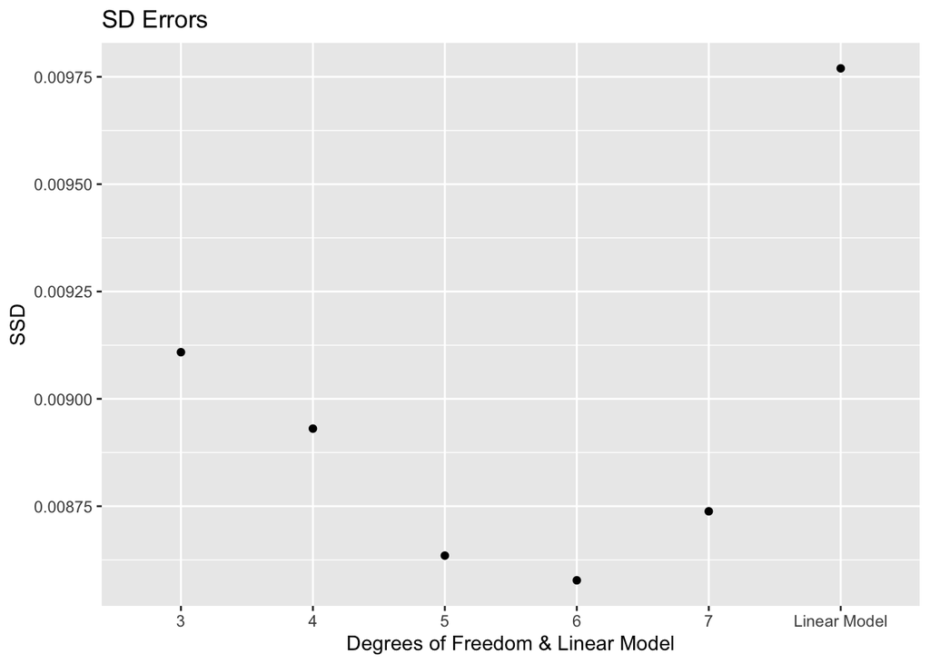

Data Frame of All Average MSE and SSD

| Model | avg_mse |
| --- | --- |
| Linear Model | 0.3686660 |
| 3 | 0.3600995 |
| 4 | 0.3584143 |
| 5 | 0.3579428 |
| 6 | 0.3582700 |
| 7 | 0.3591648 |

| Model | sd_error |
| --- | --- |
| Linear Model | 0.009769690 |
| 3 | 0.009108701 |
| 4 | 0.008930752 |
| 5 | 0.008634974 |
| 6 | 0.008577422 |
| 7 | 0.008738099 |

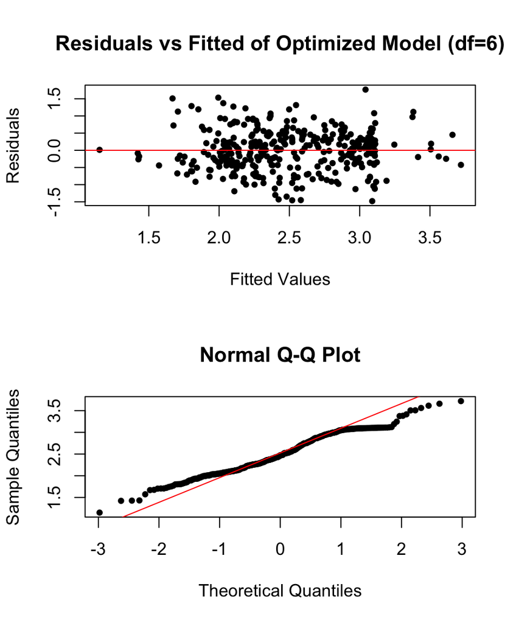

**(5)** A nonformal analysis on our best model with other model further validates its best fit for the data. Looking at the standard errors, our model has one of the most relatively low SSD, which implies that our best model is one of the most consistent.

# Results

**(1)** Let’s now officially determine whether animals with lower metabolic rates have longer lifespans. Our first key observation was that the relationship between the transformed Metabolic by Mass and Maximum Longevity Years have a negative correlation. However, due to our cross-validation we calculated in ‘Modelling and Diagnostics’, we see that the best model has 5 degrees of freedom. This implies that association is not linear. In addition, the negative correlation means that as the metabolic rate increases, the maximum longevity years decreases. This implies that the lower the animal’s metabolic rate, it is safe to predict that the lifespan would be higher.

**(2)** Now, per Preson Jorgenson’s request, let’s look into the crab-eating racoon and its features:

|  | X | HAGRID | Kingdom | Phylum | Class | Order | Family | Genus | Species | Common.name | Maximum.longevity.yrs | Body.mass.g | Metabolic.rate | Temperature | Metabolic.by.mass | log_max.long.yrs | log_metabolic.by.mass |
| --- | --- | --- | --- | --- | --- | --- | --- | --- | --- | --- | --- | --- | --- | --- | --- | --- | --- |
| 83 | 1878 | 1898 | Animalia | Chordata | Mammalia | Carnivora | Procyonidae | Procyon | cancrivorus | Crab-eating raccoon | 19 | 1160 | 2.588 | 310.15 | 0.002231034 | 2.944439 | -6.10529 |

Its metabolic rate by mass is about 0.00223 and its maximum longevity lifespan in years is 19. Now let’s calculate its metabolic rate if it would have its rate were 50% smaller. We’ll do this by first dividing its metabolic rate by mass by half and then log it: $log(0.002231034/2) = -6.798437$. Now let’s estimate its mean lifespan of an animal with those characters based on our best model that has 5 degrees of freedom. We can use non-parametric bootstrapping to do so by using the pivotal confidence interval and 1000 bootstrap iterations.

```
##
##  One Sample t-test
##
## data:  predictions
## t = 636.17, df = 999, p-value < 2.2e-16
## alternative hypothesis: true mean is not equal to 0
## 95 percent confidence interval:
##  20.15376 20.27848
## sample estimates:
## mean of x
##  20.21612
```

# Conclusions

**(1)** In conclusion, we see that there is definitely a negative correlated relationship between an animal’s maximum lifespan and their metabolic rate by mass. This means that as an animal’s metabolic rate by mass decrease, the animal’s maximum lifespan increases. All of our scatter plots and analyses showed, however, that this relationship is not exactly linear, even after transforming the variables by log. We also conducted cross-validation with 5 folds to understand the models based on transformed variables. From these multiple analyses, we can conclude that a nonlinear spline model of 5 effective degrees of freedom was the best predicting model.

**(3)** Based on the given data from AnAge Dataset, we created ‘Metabolic.by.mass’ by using ‘Metabolic.rate’ and ‘Body.mass.g’ and used it as our main explanatory variable. To claim that this one variable is the sole factor of affecting an animal’s maximum lifespan is limited. There are definitely many more factors that we could’ve explored from the AnAge Dataset and even beyond this dataset. However, it was appropriate to mainly examine an animal’s metabolic rate in order to answer our research questions. In addition, to have a clear understanding of what the research questions wanted to examine, it is also important to maintain simplicity and focusing on key variables such as ‘Metabolic.by.mass’. Overall, it would have been more interesting to observe other factors to see their interactions with maximum lifespan as well to make further discussions about the possibility of immortality.